# TASR temps brms models

# Mean Temperatures

## Conditional Effects

Here is a plot showing how the model estimates temperature change across years for each `source` category.

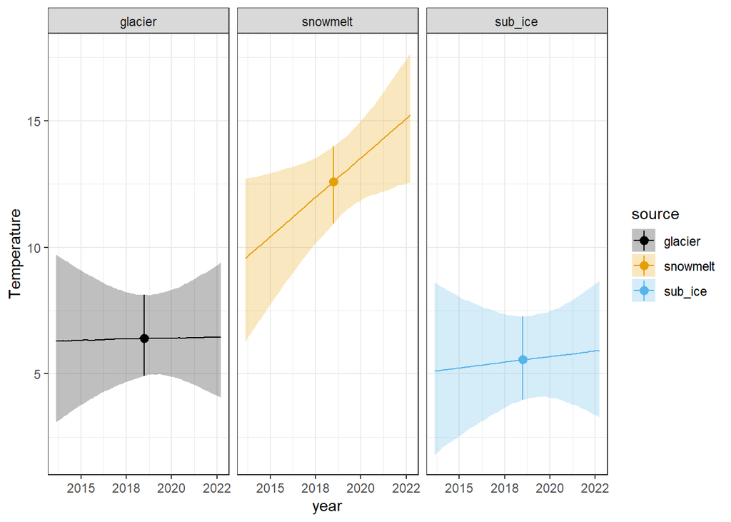

We can see a clear positive relationship for the snowmelt (yellow) streams, but less clear for the glacier and sub_ice.

## Probability that slopes are positive

```r
# Snow
mean_mod %>%
  spread_draws(b_year_s,
               `b_year_s:sourcesnowmelt`) %>%
  rename(year_snow = `b_year_s:sourcesnowmelt`) %>%
  mutate(snow = b_year_s + year_snow,
         snow_pos = snow > 0) %>%
  summarize(mean(snow_pos))
```

```
## # A tibble: 1 × 1
##   `mean(snow_pos)`
##              <dbl>
## 1            0.985
```

```r
# 98.5% +

# sub ice
mean_mod %>%
  spread_draws(b_Intercept,
               b_sourcesub_ice,
               b_year_s,
               `b_year_s:sourcesub_ice`) %>%
  rename(year_sub = `b_year_s:sourcesub_ice`) %>%
  mutate(sub = b_year_s + year_sub,
         sub_pos = sub > 0) %>%
  summarize(mean(sub_pos))
```

```
## # A tibble: 1 × 1
##   `mean(sub_pos)`
##             <dbl>
## 1           0.633
```

```r
# 63% +

# glacier
mean_mod %>%
  spread_draws(b_year_s) %>%
  mutate(year_pos = b_year_s > 0) %>%
  summarize(mean(year_pos))
```

```
## # A tibble: 1 × 1
##   `mean(year_pos)`
##              <dbl>
## 1            0.526
```

```r
# 52%  +
```

The snowmelt streams have a 98.5% probability of a positive relationship. Sub_ice has a 63.3% probability of a positive relationship. Glacier streams only have a 52.6% probability of a positive relationship.

We would basically say there is overwhelming, weak, and no evidence for these three categories increasing temperature through time, respectively.

## Rate of change across time

We can also put a “slope” estimate on these to quantify the rate of temperature change through time.

```r
# snowmelt
(fixef(mean_mod)[2,1]+fixef(mean_mod)[5,1]) * (sd_temp / sd_year)
```

```
## [1] 0.6245447
```

```r
# increase of 0.413C per year
# Sub
(fixef(mean_mod)[2,1]+fixef(mean_mod)[6,1]) * (sd_temp / sd_year)
```

```
## [1] 0.08952529
```

```r
# decrease: -0.02C per year
# glacier
fixef(mean_mod)[2,1] * (sd_temp / sd_year)
```

```
## [1] 0.02283841
```

```r
# decrease: -0.06C per year
```

The snowmelt streams have experienced an increase of 0.625 degrees C per year. The sub_ice streams have experienced an increase of 0.090 degrees C per year. The glacier streams have experienced an increase of 0.023 degrees C per year.

## Predicted temperature change next year

Just for fun, we can use these models to predict the probabilities of temperature increases next year. This is averaging across all sites and showing the overall prediction. Not sure if we want to do this for the paper, but I was having fun. We could also look at site-specific forecasts as well.

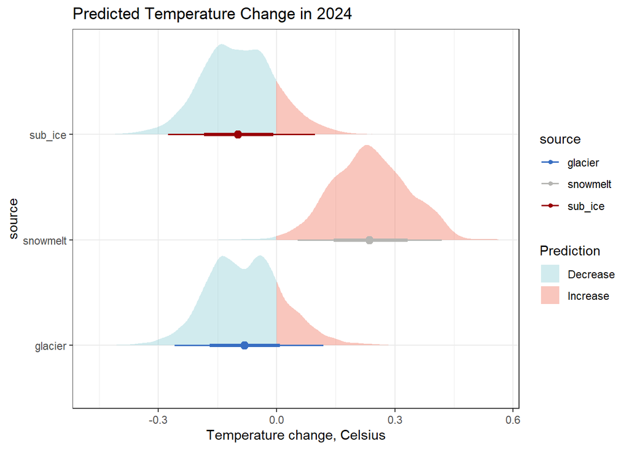

## Maximum Temperature

I include the same information as above with less text for simplicity.

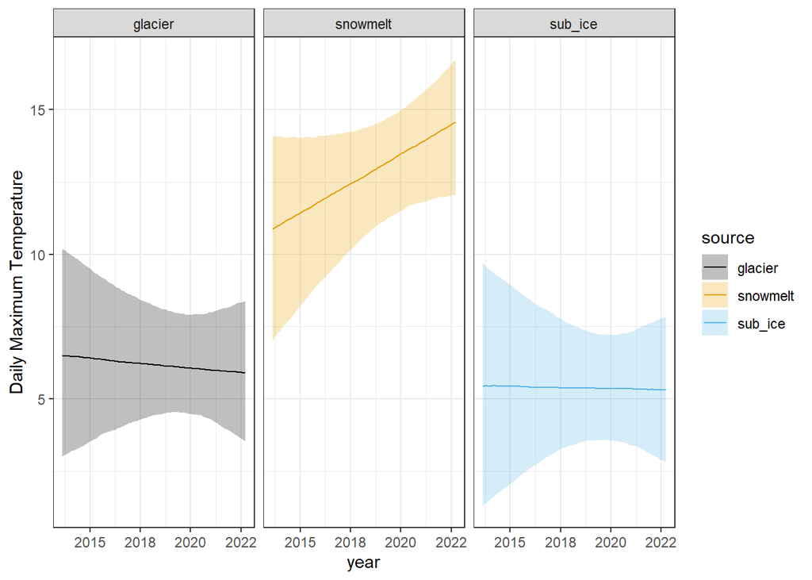

Similar as above, maximum temperature looks to be strongly increasing in snowmelt streams, and looks to be slightly decreasing or staying the same in the other two categories.

## Probability that slopes are positive

```r
# Snow
max_mod %>%
  spread_draws(b_year_s,
               `b_year_s:sourcesnowmelt`) %>%
  rename(year_snow = `b_year_s:sourcesnowmelt`) %>%
  mutate(snow = b_year_s + year_snow,
         snow_pos = snow > 0) %>%
  summarize(mean(snow_pos))
```

```
## # A tibble: 1 × 1
##   `mean(snow_pos)`
##              <dbl>
## 1            0.946
```

```r
# 95% +
# sub ice
max_mod %>%
  spread_draws(b_Intercept,
               b_sourcesub_ice,
               b_year_s,
               `b_year_s:sourcesub_ice`) %>%
  rename(year_sub = `b_year_s:sourcesub_ice`) %>%
  mutate(sub = b_year_s + year_sub,
         sub_pos = sub > 0) %>%
  summarize(mean(sub_pos))
```

```
## # A tibble: 1 × 1
##   `mean(sub_pos)`
##             <dbl>
## 1           0.468
```

```r
# 47% +
# glacier
max_mod %>%
  spread_draws(b_year_s) %>%
  mutate(year_pos = b_year_s > 0) %>%
  summarize(mean(year_pos))
```

```
## # A tibble: 1 × 1
##   `mean(year_pos)`
##              <dbl>
## 1            0.396
```

```r
# 40%  +
```

Maximum temperatures for Snowmelt has a 94.6% probability of increasing. Maximum temperatures for Sub_ice has a 46.8% probability of increasing. Maximum temperatures for Glacier has a 39.6% probability of increasing.

## Magnitude of change

```r
# snowmelt
(fixef(max_mod)[2,1]+fixef(max_mod)[5,1]) * (sd_max_temp / sd_year)
```

```
## [1] 0.4130317
```

```r
# increase of 0.413C per year
# Sub
(fixef(max_mod)[2,1]+fixef(max_mod)[6,1]) * (sd_max_temp / sd_year)
```

```
## [1] -0.01984671
```

```r
# decrease: -0.02C per year
# glacier
fixef(max_mod)[2,1] * (sd_max_temp / sd_year)
```

```
## [1] -0.06625617
```

```r
# decrease: -0.06C per year
```

Maximum temperatures for Snowmelt increasing by 0.413C per year Maximum temperatures for Sub_ice changing by -0.020C per year Maximum temperatures for Glacier changing by -0.066C per year

## Minimum Temperature

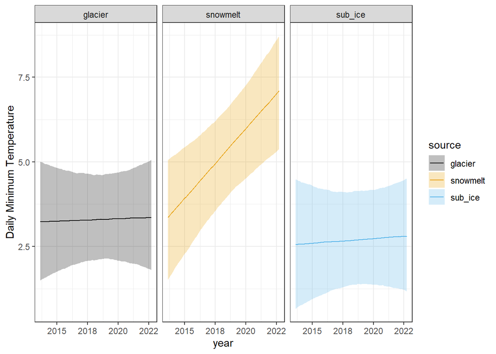

Minimum temperatures in August all seem to be increasing (although only slightly for sub and glacial streams).

## Probability that slopes are positive

```r
# Snow
min_mod %>%
  spread_draws(b_year_s,
               `b_year_s:sourcesnowmelt`) %>%
  rename(year_snow = `b_year_s:sourcesnowmelt`) %>%
  mutate(snow = b_year_s + year_snow,
         snow_pos = snow > 0) %>%
  summarize(mean(snow_pos))
```

```
## # A tibble: 1 × 1
##   `mean(snow_pos)`
##              <dbl>
## 1            0.997
```

```r
# 99% +
# sub ice
min_mod %>%
  spread_draws(b_Intercept,
               b_sourcesub_ice,
               b_year_s,
               `b_year_s:sourcesub_ice`) %>%
  rename(year_sub = `b_year_s:sourcesub_ice`) %>%
  mutate(sub = b_year_s + year_sub,
         sub_pos = sub > 0) %>%
  summarize(mean(sub_pos))
```

```
## # A tibble: 1 × 1
##   `mean(sub_pos)`
##             <dbl>
## 1           0.576
```

```r
# 58% +
# glacier
min_mod %>%
  spread_draws(b_year_s) %>%
  mutate(year_pos = b_year_s > 0) %>%
  summarize(mean(year_pos))
```

```
## # A tibble: 1 × 1
##   `mean(year_pos)`
##              <dbl>
## 1            0.550
```

```r
# 55%  +
```

Minimum temperatures for Snowmelt has a 99.7% probability of increasing. Minimum temperatures for Sub_ice has a 57.6% probability of increasing. Minimum temperatures for Glacier has a 55.0% probability of increasing.

## Magnitude of change

```r
# snowmelt
(fixef(min_mod)[2,1]+fixef(min_mod)[5,1]) * (sd_max_temp / sd_year)
```

```
## [1] 0.8154886
```

```r
# increase of 0.82C per year
# Sub
(fixef(min_mod)[2,1]+fixef(min_mod)[6,1]) * (sd_max_temp / sd_year)
```

```
## [1] 0.04824094
```

```r
# 0.05C per year
# glacier
fixef(min_mod)[2,1] * (sd_max_temp / sd_year)
```

```
## [1] 0.02886372
```

```r
# 0.03C per year
```